# Visualisatie Deel 2

```
seaborn
    Datasets Imports
    Distributieplots
    Distplots
        Distplot
        Joinplot
        Pairplot
        Parameter tuning -> Studenten Docenten
    Set
        Rugplot
    Titanic exercise -> Studenten Docenten
    Distributie categorische waardes
    Hue in pairplot
        Exercise dataset
    Boxplot
        Bonus catplot() -> Studenten Docenten
    Viz-keuze -> Meenemen naar huis, bespreken wat voor plots wanneer gebruikt worden
    Matrix plots
        Actie (ca 30 min)
            Bekijk parameters -> Studenten Docenten
            Evaluatie -> Studenten Docenten
            Heathmap
    Corr styling
        Actie -> Studenten Docenten
    Seaborn op fig.axes
        Functies voor stijl-opties
        Extra -> Studenten Docenten
```

### Nodige import van Titanic

```python
import pandas as pd
Data = pd.read_csv('data/fulltitanic.csv')
TVis = Data[Data['Survived'].notnull()]
```

# Seaborn!

arrrr

- Ontworpen om naadloos te passen op pandas' DataFrame
- Stijlvolle en gebruiksvriendelijke default stijlen
- Opensource (dus op Github)

https://github.com/mwaskom/seaborn  
https://seaborn.pydata.org/

Seaborn komt met Standaar datasets.  
Zichtbaar met sns.get_dataset_names()

```python
import seaborn as sns
```

## Datasets imports

```python
sns.get_dataset_names()
```

```
['anscombe',
 'attention',
 'brain_networks',
 'car_crashes',
 'diamonds',
 'dots',
 'exercise',
 'flights',
 'fmri',
 'gammas',
 'iris',
 'mpg',
 'planets',
 'tips',
 'titanic']
```

```python
crashes = sns.load_dataset('car_crashes')
```

## Distributieplots

Visualiseer de univariante set observaties  
De distributie van een kolom

We gaan kijken naar:  
**distplot** Distributie van continue variabele  
**jointplot** Distributie van twee variabelen tegenover elkaar  
**pairplot** Vergelijk distributie van alle numerieke variabelen  
**rugplot** Voor precieze plaatsing op x-as van distributies

```python
# Show sns.distplot() input parameters
# sns.distplot()
```

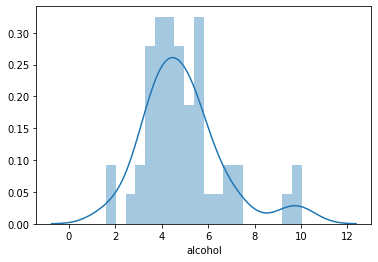

```python
sns.distplot(crashes['alcohol'], bins=20)
```

```python
# Show sns.jointplot() input parameters
# sns.jointplot()
```

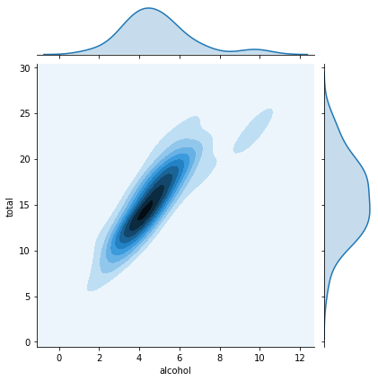

```python
sns.jointplot(x='alcohol' , y='total', data=crashes, kind='kde')
```

## Speel met de waarde mogelijke parameters van Kind

kind : { "scatter" | "reg" | "resid" | "kde" | "hex" }

Hoe veranderd een andere visualisatie het inzicht?

```python
# Show sns.pairplot() input parameters
# sns.pairplot()
```

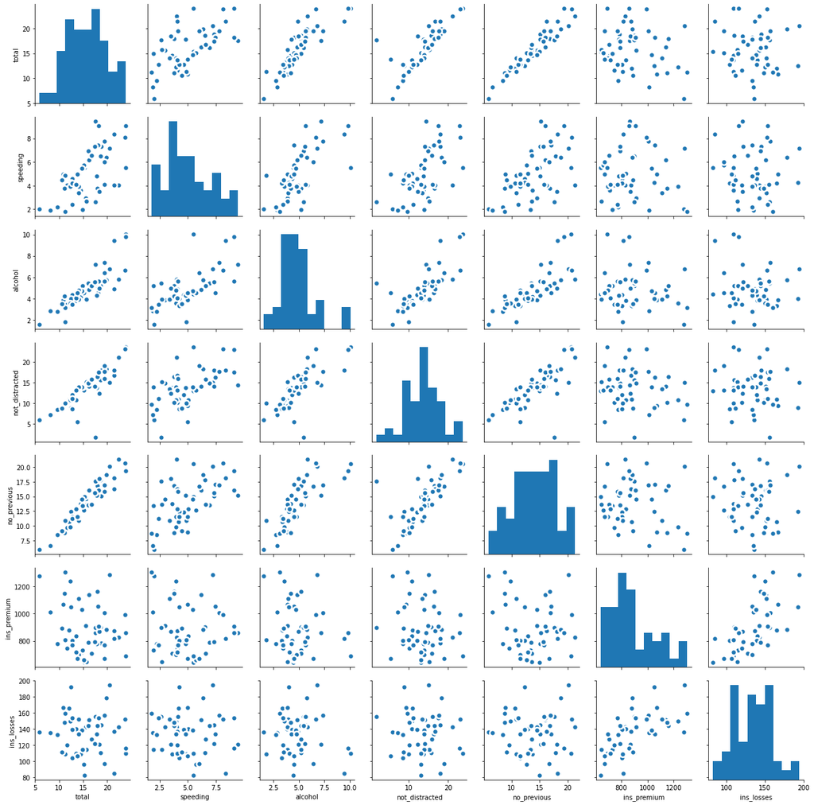

```python
sns.pairplot(crashes, plot_kws=dict(s=80, edgecolor="white", linewidth=2.5))
```

# Set

Set, heeft een eental fantastische attributen om de stijl te veranderen. En zoals in veel dependency pakketen kunnen we met *kwargs* kwasi-arguments  
Ook waardes veranderen in het onderliggende matplotlib Framework.

**Speel met de standaardwaarden:**  
style='darkgrid',  
palette='deep',  
font='sans-serif',  
font_scale=1,  
color_codes=True,  
rc=None

Welke waarden kunnen we nog maar invoeren bij:  
context='notebook'?

naslag: https://seaborn.pydata.org/tutorial/aesthetics.html https://seaborn.pydata.org/tutorial/color_palettes.html

### Palette

Het kiezen van een palette lijkt onbelangrijk, maar het kiezen van de juiste kleuren zegt veel over wat je precies wilt laten zien.

```python
current_palette = sns.color_palette()
current_palette
```

```
[(0.12156862745098039, 0.4666666666666667, 0.7058823529411765),
 (1.0, 0.4980392156862745, 0.054901960784313725),
 (0.17254901960784313, 0.6274509803921569, 0.17254901960784313),
 (0.8392156862745098, 0.15294117647058825, 0.1568627450980392),
 (0.5803921568627451, 0.403921568627451, 0.7411764705882353),
 (0.5490196078431373, 0.33725490196078434, 0.29411764705882354),
 (0.8901960784313725, 0.4666666666666667, 0.7607843137254902),
 (0.4980392156862745, 0.4980392156862745, 0.4980392156862745),
 (0.7372549019607844, 0.7411764705882353, 0.13333333333333333),
 (0.09019607843137255, 0.7450980392156863, 0.8117647058823529)]
```

Kleuren zijn gewoon color codes! Als je deze wilt weergeven:

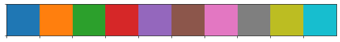

```python
sns.palplot(current_palette)
```

Aanpassen van kleuren met "hsul", welke rekening houdt met gelijke licht en verzadiging distributie.

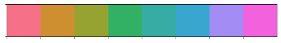

```python
sns.palplot(sns.color_palette("husl", 8))
```

Of kies zelf je kleurwaardes uit naar believen.

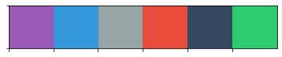

```python
flatui = ["#9b59b6", "#3498db", "#95a5a6", "#e74c3c", "#34495e", "#2ecc71"]
sns.palplot(sns.color_palette(flatui))
```

```python
sns.set(palette='husl', rc={"axes.facecolor": "#967aa0"})
```

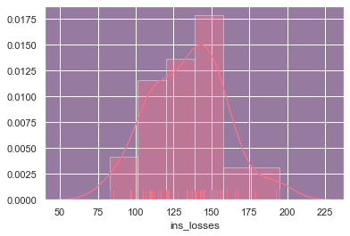

```python
sns.rugplot(crashes['ins_losses'])
sns.distplot(crashes['ins_losses'])
```

## Titanixercise.

Gebruik jointplot voor de continue variabelen van TVis

**tip:**  
Kijk naar de xlim en ylim variabelen

```python
TVis = TVis.rename(columns={"Fare_fill": "Fare_mean"})
TVis.head()
```

|  | Unnamed: 0 | Age | Cabin | Embarked | Fare | Name | Parch | PassengerId | Pclass | Sex | ... | Title | Age_mean | Fare_mean | Embarked_fill | Age_fill | Cabin_fill | FamilySize | Family_Single | Family_Small | Family_Large |
| --- | --- | --- | --- | --- | --- | --- | --- | --- | --- | --- | --- | --- | --- | --- | --- | --- | --- | --- | --- | --- | --- |
| 0 | 0 | 22.0 | NaN | S | 7.2500 | Braund, Mr. Owen Harris | 0 | 1 | 3 | male | ... | Mr | 22.0 | 7.2500 | S | 22.0 | U | 2 | 0 | 1 | 0 |
| 1 | 1 | 38.0 | C85 | C | 71.2833 | Cumings, Mrs. John Bradley (Florence Briggs Th... | 0 | 2 | 1 | female | ... | Mrs | 38.0 | 71.2833 | C | 38.0 | C | 2 | 0 | 1 | 0 |
| 2 | 2 | 26.0 | NaN | S | 7.9250 | Heikkinen, Miss. Laina | 0 | 3 | 3 | female | ... | Miss | 26.0 | 7.9250 | S | 26.0 | U | 1 | 1 | 0 | 0 |
| 3 | 3 | 35.0 | C123 | S | 53.1000 | Futrelle, Mrs. Jacques Heath (Lily May Peel) | 0 | 4 | 1 | female | ... | Mrs | 35.0 | 53.1000 | S | 35.0 | C | 2 | 0 | 1 | 0 |
| 4 | 4 | 35.0 | NaN | S | 8.0500 | Allen, Mr. William Henry | 0 | 5 | 3 | male | ... | Mr | 35.0 | 8.0500 | S | 35.0 | U | 1 | 1 | 0 | 0 |

5 rows × 23 columns

```python
# sns.distplot()
```

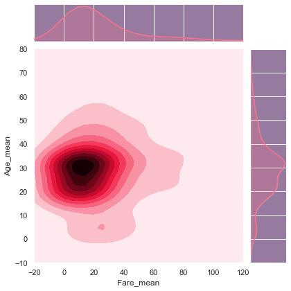

```python
sns.jointplot(x='Fare_mean' , y='Age_mean', data=TVis, kind='kde', xlim=(-20,120),
    ylim=(-10,80))
```

### distributie van categorische waardes

```python
TVis.rename(columns={"Embarked_fill": "Embarked_max"}).head()
```

|  | Unnamed: 0 | Age | Cabin | Embarked | Fare | Name | Parch | PassengerId | Pclass | Sex | ... | Title | Age_mean | Fare_mean | Embarked_max | Age_fill | Cabin_fill | FamilySize | Family_Single | Family_Small | Family_Large |
| --- | --- | --- | --- | --- | --- | --- | --- | --- | --- | --- | --- | --- | --- | --- | --- | --- | --- | --- | --- | --- | --- |
| 0 | 0 | 22.0 | NaN | S | 7.2500 | Braund, Mr. Owen Harris | 0 | 1 | 3 | male | ... | Mr | 22.0 | 7.2500 | S | 22.0 | U | 2 | 0 | 1 | 0 |
| 1 | 1 | 38.0 | C85 | C | 71.2833 | Cumings, Mrs. John Bradley (Florence Briggs Th... | 0 | 2 | 1 | female | ... | Mrs | 38.0 | 71.2833 | C | 38.0 | C | 2 | 0 | 1 | 0 |
| 2 | 2 | 26.0 | NaN | S | 7.9250 | Heikkinen, Miss. Laina | 0 | 3 | 3 | female | ... | Miss | 26.0 | 7.9250 | S | 26.0 | U | 1 | 1 | 0 | 0 |
| 3 | 3 | 35.0 | C123 | S | 53.1000 | Futrelle, Mrs. Jacques Heath (Lily May Peel) | 0 | 4 | 1 | female | ... | Mrs | 35.0 | 53.1000 | S | 35.0 | C | 2 | 0 | 1 | 0 |
| 4 | 4 | 35.0 | NaN | S | 8.0500 | Allen, Mr. William Henry | 0 | 5 | 3 | male | ... | Mr | 35.0 | 8.0500 | S | 35.0 | U | 1 | 1 | 0 | 0 |

5 rows × 23 columns

```python
TVis.rename(columns={"Fare_fill": "Fare_mean"}).head()
```

|  | Unnamed: 0 | Age | Cabin | Embarked | Fare | Name | Parch | PassengerId | Pclass | Sex | ... | Title | Age_mean | Fare_mean | Embarked_fill | Age_fill | Cabin_fill | FamilySize | Family_Single | Family_Small | Family_Large |
| --- | --- | --- | --- | --- | --- | --- | --- | --- | --- | --- | --- | --- | --- | --- | --- | --- | --- | --- | --- | --- | --- |
| 0 | 0 | 22.0 | NaN | S | 7.2500 | Braund, Mr. Owen Harris | 0 | 1 | 3 | male | ... | Mr | 22.0 | 7.2500 | S | 22.0 | U | 2 | 0 | 1 | 0 |
| 1 | 1 | 38.0 | C85 | C | 71.2833 | Cumings, Mrs. John Bradley (Florence Briggs Th... | 0 | 2 | 1 | female | ... | Mrs | 38.0 | 71.2833 | C | 38.0 | C | 2 | 0 | 1 | 0 |
| 2 | 2 | 26.0 | NaN | S | 7.9250 | Heikkinen, Miss. Laina | 0 | 3 | 3 | female | ... | Miss | 26.0 | 7.9250 | S | 26.0 | U | 1 | 1 | 0 | 0 |
| 3 | 3 | 35.0 | C123 | S | 53.1000 | Futrelle, Mrs. Jacques Heath (Lily May Peel) | 0 | 4 | 1 | female | ... | Mrs | 35.0 | 53.1000 | S | 35.0 | C | 2 | 0 | 1 | 0 |
| 4 | 4 | 35.0 | NaN | S | 8.0500 | Allen, Mr. William Henry | 0 | 5 | 3 | male | ... | Mr | 35.0 | 8.0500 | S | 35.0 | U | 1 | 1 | 0 | 0 |

5 rows × 23 columns

```python
TVis.keys()
```

```
Index(['Unnamed: 0', 'Age', 'Cabin', 'Embarked', 'Fare', 'Name', 'Parch',
       'PassengerId', 'Pclass', 'Sex', 'SibSp', 'Survived', 'Ticket', 'Title',
       'Age_mean', 'Fare_mean', 'Embarked_fill', 'Age_fill', 'Cabin_fill',
       'FamilySize', 'Family_Single', 'Family_Small', 'Family_Large'],
      dtype='object')
```

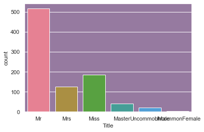

```python
sns.countplot(x='Title', data= TVis)
```

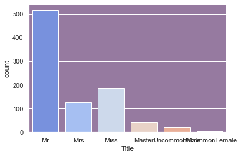

```python
sns.countplot(x='Title', data= TVis, palette='coolwarm')
```

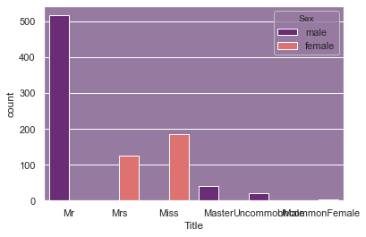

```python
sns.countplot(x='Title', data= TVis, hue='Sex', palette='magma')
```

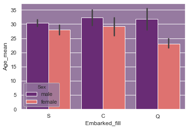

```python
sns.barplot(x='Embarked_fill', y='Age_mean', hue='Sex', data=TVis, palette='magma')
```

# Hue in pairplot!

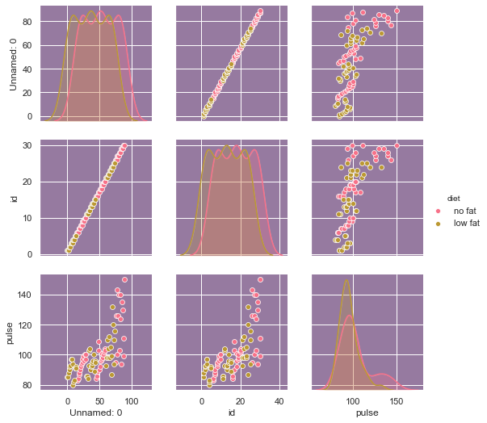

```python
exercise = sns.load_dataset('exercise')
sns.pairplot(exercise, hue='diet')
```

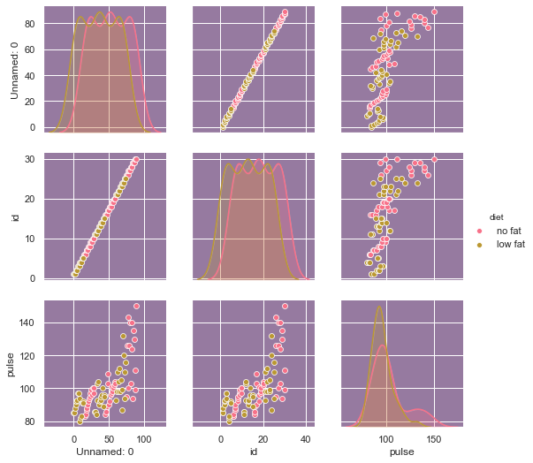

```python
sns.pairplot(exercise, hue='diet')
sns.set(palette='coolwarm', rc={"axes.facecolor": "#967aa0"})
```

# Boxplot 2.0

Mooiere, makkelijker plotbare boxplots.

En supereenvoudige:  
violin, strip & swarmplots

Super voor distributie per attribuut of categorie

```python
TVis = TVis.rename(columns={"Embarked_fill": "Embarked_max"})
```

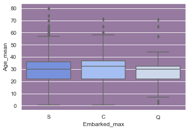

```python
sns.boxplot(x='Embarked_max', y='Age_mean', data=TVis)
```

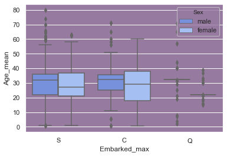

```python
sns.boxplot(x='Embarked_max', y='Age_mean', data=TVis, hue='Sex')
```

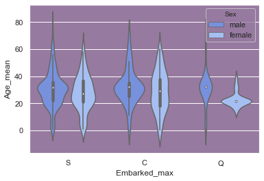

```python
sns.violinplot(x='Embarked_max', y='Age_mean', hue='Sex', data=TVis)
```

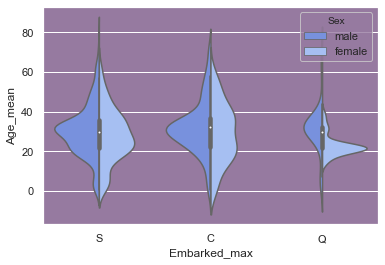

```python
sns.violinplot(x='Embarked_max', y='Age_mean', hue='Sex', data=TVis, split = True)
```

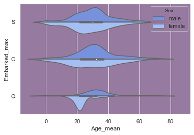

```python
sns.violinplot(x='Age_mean', y='Embarked_max', hue='Sex', data=TVis, split = True)
```

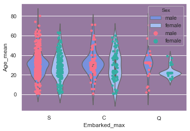

```python
sns.violinplot(x='Embarked_max', y='Age_mean', hue='Sex', data=TVis)
sns.stripplot(x='Embarked_max', y='Age_mean', hue='Sex', data=TVis, dodge=True, palette='husl' )
```

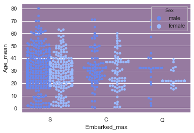

```python
sns.swarmplot(x='Embarked_max', y='Age_mean', hue='Sex', data=TVis, dodge=True)  #color veranderen voor points
# sns.violinplot(x= 'time', y= 'pulse', data=exercise, hue='diet', dodge=True)
```

## Bonus: look at catplot()

Wat doet met de 'kind' paramater?

Options are: “point”, “bar”, “strip”, “swarm”, “box”, “violin”, or “boxen”. Probeer een aantal van deze parameter instelling uit.

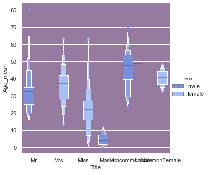

```python
sns.catplot(x= 'Title', y= 'Age_mean', data=TVis, hue='Sex', kind='boxen')
```

# Viz-keuze

Bespreek met manager/collega's/bussiness-user welke plots goed leesbaar zijn.

# Matrix plots (heatmaps!)

Voor distibutie-overzicht van grotere variabelen.

bijvoorbeeld Jaargangen tov maanden

Data heeft zo een matrix-vorm.  
Index naam en kolomnaam zijn gelinkt in de cel.

```python
flights = sns.load_dataset('flights')
```

```python
flights.keys()
```

```
Index(['year', 'month', 'passengers'], dtype='object')
```

```python
fp = flights.pivot_table(index='month', columns='year', values='passengers')
```

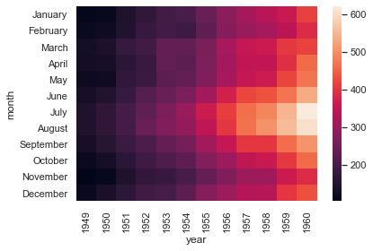

```python
sns.heatmap(fp)
```

# Actie:

Visualiseer de TitanicData in een heatmap.  
Welke attributen kunnen we goed tegenover elkaar zetten?

Welke conclusies kunnen we trekken?

### Bekijk de parameters:

- annot
- cmap
- linewidth
- linecolor

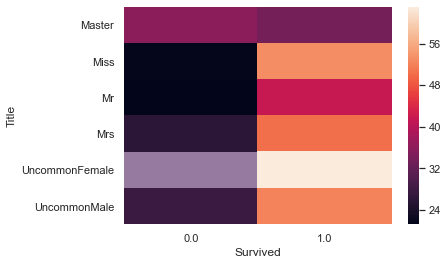

```python
# Code

fp = TVis.pivot_table(index='Title', columns='Survived', values='Fare')
sns.heatmap(fp)
```

# o!

Juist... wat valt ons op aan de heatmap plot?

https://stackoverflow.com/questions/56942670/matplotlib-seaborn-first-and-last-row-cut-in-half-of-heatmap-plot

```
(7.5, -0.5)
```

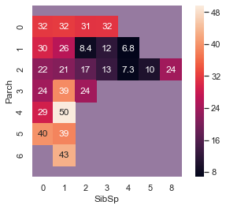

```python
import matplotlib.pyplot as plt

TitanicPivit = TVis.pivot_table(index='Parch', columns='SibSp', values='Age_mean')

ax = sns.heatmap(TitanicPivit, annot=True, square = True)
bottom, top = ax.get_ylim()
ax.set_ylim(bottom + 0.5, top - 0.5)
```

```
(15.5, -0.5)
```

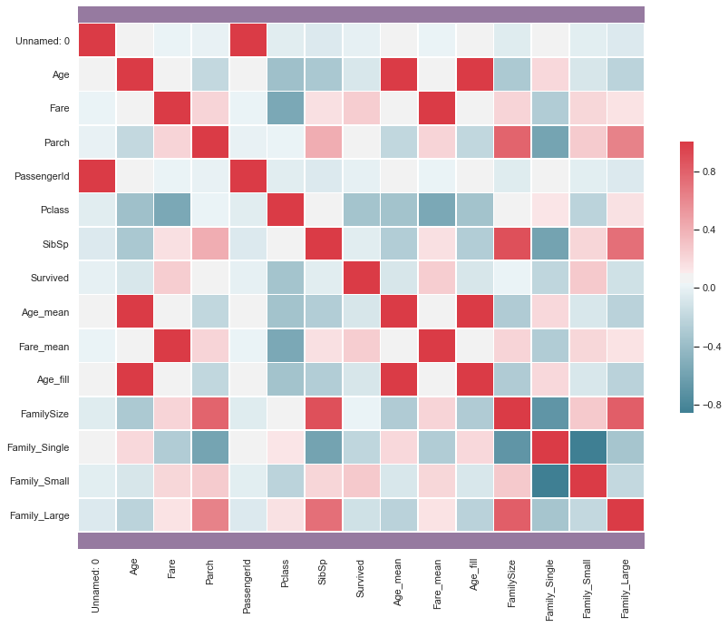

```python
corr = TVis.corr()
cmap = sns.diverging_palette(220, 10, as_cmap=True) #, center="dark"

plt.figure(figsize=(14, 11))
ax = sns.heatmap(corr, cmap=cmap,vmax=1,linewidths=.6, cbar_kws={"shrink": 0.5})
bottom, top = ax.get_ylim()
ax.set_ylim(bottom + 0.5, top - 0.5)
```

# Meer Corr-stylings!

En meer dan het styleren van je correlatieplot.

Pandas style functie geeft onwijs veel toffe mogelijkheden  
Voor het inkleuren van je matrixen, dus ook je dataframes.

Voor meer styling mogelijkheden, zie:  
https://pandas.pydata.org/pandas-docs/stable/user_guide/style.html

```python
def color_value(value):

    if (value < 0 and value > -1):
        color = 'red'
    elif (value > 0 and value < 1):
        color = 'green'
    else:
        color = 'black'

    return 'color: %s' % color
```

```python
corr.style.applymap(color_value)
```

|  | Unnamed: 0 | Age | Fare | Parch | PassengerId | Pclass | SibSp | Survived | Age_mean | Fare_mean | Age_fill | FamilySize | Family_Single | Family_Small | Family_Large |
| --- | --- | --- | --- | --- | --- | --- | --- | --- | --- | --- | --- | --- | --- | --- | --- |
| Unnamed: 0 | 1 | 0.0368472 | 0.0126582 | -0.00165201 | 1 | -0.035144 | -0.0575268 | -0.00500666 | 0.042219 | 0.0126582 | 0.042219 | -0.0401429 | 0.0574619 | -0.0289764 | -0.0570549 |
| Age | 0.0368472 | 1 | 0.0960667 | -0.189119 | 0.0368472 | -0.369226 | -0.308247 | -0.0772211 | 1 | 0.0960667 | 1 | -0.301914 | 0.19827 | -0.0830586 | -0.226521 |
| Fare | 0.0126582 | 0.0960667 | 1 | 0.216225 | 0.0126582 | -0.5495 | 0.159651 | 0.257307 | 0.0918639 | 1 | 0.0918639 | 0.217138 | -0.271832 | 0.205527 | 0.143636 |
| Parch | -0.00165201 | -0.189119 | 0.216225 | 1 | -0.00165201 | 0.0184427 | 0.414838 | 0.0816294 | -0.196288 | 0.216225 | -0.196288 | 0.783111 | -0.583398 | 0.265863 | 0.631523 |
| PassengerId | 1 | 0.0368472 | 0.0126582 | -0.00165201 | 1 | -0.035144 | -0.0575268 | -0.00500666 | 0.042219 | 0.0126582 | 0.042219 | -0.0401429 | 0.0574619 | -0.0289764 | -0.0570549 |
| Pclass | -0.035144 | -0.369226 | -0.5495 | 0.0184427 | -0.035144 | 1 | 0.0830814 | -0.338481 | -0.344474 | -0.5495 | -0.344474 | 0.0659969 | 0.135207 | -0.223551 | 0.152366 |
| SibSp | -0.0575268 | -0.308247 | 0.159651 | 0.414838 | -0.0575268 | 0.0830814 | 1 | -0.0353225 | -0.266596 | 0.159651 | -0.266596 | 0.890712 | -0.584471 | 0.213225 | 0.730691 |
| Survived | -0.00500666 | -0.0772211 | 0.257307 | 0.0816294 | -0.00500666 | -0.338481 | -0.0353225 | 1 | -0.0872628 | 0.257307 | -0.0872628 | 0.016639 | -0.203367 | 0.279855 | -0.125147 |
| Age_mean | 0.042219 | 1 | 0.0918639 | -0.196288 | 0.042219 | -0.344474 | -0.266596 | -0.0872628 | 1 | 0.0918639 | 1 | -0.280272 | 0.19413 | -0.0768127 | -0.231645 |
| Fare_mean | 0.0126582 | 0.0960667 | 1 | 0.216225 | 0.0126582 | -0.5495 | 0.159651 | 0.257307 | 0.0918639 | 1 | 0.0918639 | 0.217138 | -0.271832 | 0.205527 | 0.143636 |
| Age_fill | 0.042219 | 1 | 0.0918639 | -0.196288 | 0.042219 | -0.344474 | -0.266596 | -0.0872628 | 1 | 0.0918639 | 1 | -0.280272 | 0.19413 | -0.0768127 | -0.231645 |
| FamilySize | -0.0401429 | -0.301914 | 0.217138 | 0.783111 | -0.0401429 | 0.0659969 | 0.890712 | 0.016639 | -0.280272 | 0.217138 | -0.280272 | 1 | -0.690922 | 0.278553 | 0.814901 |
| Family_Single | 0.0574619 | 0.19827 | -0.271832 | -0.583398 | 0.0574619 | 0.135207 | -0.584471 | -0.203367 | 0.19413 | -0.271832 | 0.19413 | -0.690922 | 1 | -0.859931 | -0.336825 |
| Family_Small | -0.0289764 | -0.0830586 | 0.205527 | 0.265863 | -0.0289764 | -0.223551 | 0.213225 | 0.279855 | -0.0768127 | 0.205527 | -0.0768127 | 0.278553 | -0.859931 | 1 | -0.19094 |
| Family_Large | -0.0570549 | -0.226521 | 0.143636 | 0.631523 | -0.0570549 | 0.152366 | 0.730691 | -0.125147 | -0.231645 | 0.143636 | -0.231645 | 0.814901 | -0.336825 | -0.19094 | 1 |

```python
corr.style.background_gradient(cmap=cmap)
```

|  | Unnamed: 0 | Age | Fare | Parch | PassengerId | Pclass | SibSp | Survived | Age_mean | Fare_mean | Age_fill | FamilySize | Family_Single | Family_Small | Family_Large |
| --- | --- | --- | --- | --- | --- | --- | --- | --- | --- | --- | --- | --- | --- | --- | --- |
| Unnamed: 0 | 1 | 0.0368472 | 0.0126582 | -0.00165201 | 1 | -0.035144 | -0.0575268 | -0.00500666 | 0.042219 | 0.0126582 | 0.042219 | -0.0401429 | 0.0574619 | -0.0289764 | -0.0570549 |
| Age | 0.0368472 | 1 | 0.0960667 | -0.189119 | 0.0368472 | -0.369226 | -0.308247 | -0.0772211 | 1 | 0.0960667 | 1 | -0.301914 | 0.19827 | -0.0830586 | -0.226521 |
| Fare | 0.0126582 | 0.0960667 | 1 | 0.216225 | 0.0126582 | -0.5495 | 0.159651 | 0.257307 | 0.0918639 | 1 | 0.0918639 | 0.217138 | -0.271832 | 0.205527 | 0.143636 |
| Parch | -0.00165201 | -0.189119 | 0.216225 | 1 | -0.00165201 | 0.0184427 | 0.414838 | 0.0816294 | -0.196288 | 0.216225 | -0.196288 | 0.783111 | -0.583398 | 0.265863 | 0.631523 |
| PassengerId | 1 | 0.0368472 | 0.0126582 | -0.00165201 | 1 | -0.035144 | -0.0575268 | -0.00500666 | 0.042219 | 0.0126582 | 0.042219 | -0.0401429 | 0.0574619 | -0.0289764 | -0.0570549 |
| Pclass | -0.035144 | -0.369226 | -0.5495 | 0.0184427 | -0.035144 | 1 | 0.0830814 | -0.338481 | -0.344474 | -0.5495 | -0.344474 | 0.0659969 | 0.135207 | -0.223551 | 0.152366 |
| SibSp | -0.0575268 | -0.308247 | 0.159651 | 0.414838 | -0.0575268 | 0.0830814 | 1 | -0.0353225 | -0.266596 | 0.159651 | -0.266596 | 0.890712 | -0.584471 | 0.213225 | 0.730691 |
| Survived | -0.00500666 | -0.0772211 | 0.257307 | 0.0816294 | -0.00500666 | -0.338481 | -0.0353225 | 1 | -0.0872628 | 0.257307 | -0.0872628 | 0.016639 | -0.203367 | 0.279855 | -0.125147 |
| Age_mean | 0.042219 | 1 | 0.0918639 | -0.196288 | 0.042219 | -0.344474 | -0.266596 | -0.0872628 | 1 | 0.0918639 | 1 | -0.280272 | 0.19413 | -0.0768127 | -0.231645 |
| Fare_mean | 0.0126582 | 0.0960667 | 1 | 0.216225 | 0.0126582 | -0.5495 | 0.159651 | 0.257307 | 0.0918639 | 1 | 0.0918639 | 0.217138 | -0.271832 | 0.205527 | 0.143636 |
| Age_fill | 0.042219 | 1 | 0.0918639 | -0.196288 | 0.042219 | -0.344474 | -0.266596 | -0.0872628 | 1 | 0.0918639 | 1 | -0.280272 | 0.19413 | -0.0768127 | -0.231645 |
| FamilySize | -0.0401429 | -0.301914 | 0.217138 | 0.783111 | -0.0401429 | 0.0659969 | 0.890712 | 0.016639 | -0.280272 | 0.217138 | -0.280272 | 1 | -0.690922 | 0.278553 | 0.814901 |
| Family_Single | 0.0574619 | 0.19827 | -0.271832 | -0.583398 | 0.0574619 | 0.135207 | -0.584471 | -0.203367 | 0.19413 | -0.271832 | 0.19413 | -0.690922 | 1 | -0.859931 | -0.336825 |
| Family_Small | -0.0289764 | -0.0830586 | 0.205527 | 0.265863 | -0.0289764 | -0.223551 | 0.213225 | 0.279855 | -0.0768127 | 0.205527 | -0.0768127 | 0.278553 | -0.859931 | 1 | -0.19094 |
| Family_Large | -0.0570549 | -0.226521 | 0.143636 | 0.631523 | -0.0570549 | 0.152366 | 0.730691 | -0.125147 | -0.231645 | 0.143636 | -0.231645 | 0.814901 | -0.336825 | -0.19094 | 1 |

# Actie!

Als je alleen wilt conditioneren op bijvoorbeeld `Survived` dan moet je de parameter `subset=['Survived']` toevoegen.

```python
def color_value(value):

    if value < 0.4:
        color = 'red'
    elif value > 0.6:
        color = 'green'
    else:
        color = 'black'

    return 'color: %s' % color

TVis.groupby(['Pclass', 'Sex']).mean().style.applymap(color_value, subset=['Survived'])
```

| Pclass | Sex | Unnamed: 0 | Age | Fare | Parch | PassengerId | SibSp | Survived | Age_mean | Fare_mean | Age_fill | FamilySize | Family_Single | Family_Small | Family_Large |
| --- | --- | --- | --- | --- | --- | --- | --- | --- | --- | --- | --- | --- | --- | --- | --- |
| 1 | female | 468.213 | 34.6118 | 106.126 | 0.457447 | 469.213 | 0.553191 | 0.968085 | 34.672 | 106.126 | 34.672 | 2.01064 | 0.361702 | 0.595745 | 0.0425532 |
|  | male | 454.73 | 41.2814 | 67.2261 | 0.278689 | 455.73 | 0.311475 | 0.368852 | 39.8382 | 67.2261 | 39.8382 | 1.59016 | 0.614754 | 0.368852 | 0.0163934 |
| 2 | female | 442.105 | 28.723 | 21.9701 | 0.605263 | 443.105 | 0.486842 | 0.921053 | 28.5414 | 21.9701 | 28.5414 | 2.09211 | 0.421053 | 0.552632 | 0.0263158 |
|  | male | 446.963 | 30.7407 | 19.7418 | 0.222222 | 447.963 | 0.342593 | 0.157407 | 30.8667 | 19.7418 | 30.8667 | 1.56481 | 0.666667 | 0.333333 | 0 |
| 3 | female | 398.729 | 21.75 | 16.1188 | 0.798611 | 399.729 | 0.895833 | 0.5 | 22.7151 | 16.1188 | 22.7151 | 2.69444 | 0.416667 | 0.395833 | 0.1875 |
|  | male | 454.516 | 26.5076 | 12.6616 | 0.224784 | 455.516 | 0.498559 | 0.135447 | 27.7552 | 12.6616 | 27.7552 | 1.72334 | 0.760807 | 0.161383 | 0.0778098 |

# Seaborn op fig.axes

We kunnen de meeste seaborn plots op matplotlibs axes plaats plotten.  
Via de ax, parameter.  
Dit geld helaas niet voor plots die berusten op FacetGrid()...

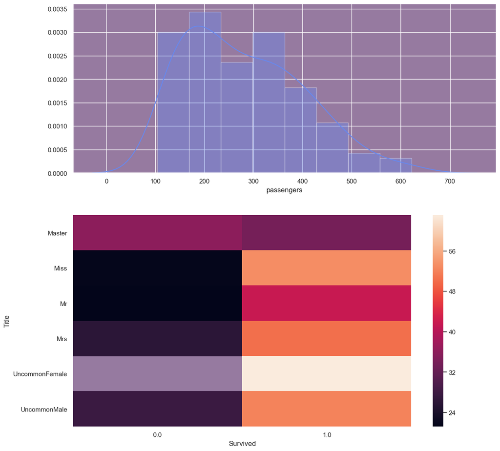

```python
fig = plt.figure(figsize=(10,10), dpi=100)

axes = fig.add_axes([0, 0, 1, 0.5])
axes2 = fig.add_axes([0, 0.6, 1, 0.4])

sns.heatmap(fp, ax=axes)
sns.distplot(flights['passengers'], ax=axes2)
```

# Functies voor stijl-opties!

- sns.set_style('white')
- sns.set_context('poster',font_scale=4)
- sns.set_style('ticks')
- sns.despine()

# Extra Titanic

```python
# Uitwerkingen hiervoor zijn nog niet door de docenten gemaakt, exuus!
```